# First aid voor fruitmandtelling met Python

## Nuttige libraries

Volgende libraries kunnen nuttig zijn tijdens de hackathon. Voel je echter vrij om libraries te gebruiken die niet in de lijst staan. Indien onderstaande libraries nog niet geinstalleerd zijn op je toestel dien je dit uiteraard nog te doen, f.e. via pip install.

### Standaard libraries voor python data analytics.

```python
import pandas as pd
import numpy as np
import matplotlib.pyplot as plt
import random
```

### Lezen en interageren met je local file system.

```python
from os import listdir
from os.path import isfile, join
```

Voor het ophalen van data via een url.

```python
import urllib.request
import requests
from io import BytesIO
```

### Capteren en verwerken van image data.

```python
from PIL import Image
from PIL.ImageEnhance import Color, Contrast, Brightness
```

### Bouwen van een neuraal netwerk.

```python
from tensorflow.keras.models import Model as tf_Model
from tensorflow.keras.layers import Flatten, Dense, Conv2D, Dropout, MaxPooling2D
from tensorflow.keras import optimizers as tf_optim
```

### Klassieke machine learning techniques

Klassieke ensemble techniek voor voorspellingen.

```python
from sklearn.ensemble import AdaBoostRegressor
```

Dataset opsplitsen in training (, validatie) en test set

```python
from sklearn.model_selection import train_test_split, KFold, StratifiedKFold
```

Normalisatie en one-hot encoding.

```python
from sklearn.preprocessing import MinMaxScaler, StandardScaler, Normalizer, OneHotEncoder
```

Berekenen van accuraatheid en vergelijken van resultaten.

```python
import sklearn.metrics as metrics
```

## Transfer - learning

Reeds getrainde modellen.

https://www.tensorflow.org/api_docs/python/tf/keras/applications

## Voorbeeldcode

### Inlezen van image data

```python
git_url = "https://raw.githubusercontent.com/marcusklasson/GroceryStoreDataset/master/dataset"
git_sub_folder = "/train/Fruit/Apple/Golden-Delicious/"
image_name = 'Golden-Delicious_001.jpg'
response = requests.get(git_url + git_sub_folder + image_name)
image = Image.open(BytesIO(response.content))
```

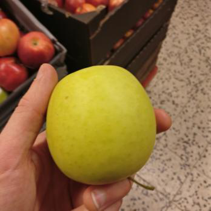

```python
image
```

```python
image = Image.open("pictures/20221013_165620.jpg")
```

```python
image.size
```

```
(4000, 3000)
```

```python
image = image.resize((400,300))
```

[figure not shown]

```python
image
```

Other documentation on reading image files from drive.

https://www.geeksforgeeks.org/python-pil-image-open-method/

### Image preprocessing

Gecentraliseerd croppen van afbeeldingen die groter zijn dan de opgegeven dimensies. Het toepassen van deze functie kan het effect hebben dat niet alles van de originele afbeelding nog zichtbaar is in de gecropte afbeelding.

```python
def crop_to_dim(pil_img, expected_height, expected_width):
    width, height = pil_img.size

    if(width > expected_width):
        left = ( width-expected_width ) / 2
        right = width - left
    else:
        left = 0
        right = width

    if(height > expected_height):
        top = ( height - expected_height ) / 2
        bottom = height - top
    else:
        top = 0
        bottom = height

    im_cropped = pil_img.crop((left, top, right, bottom))

    return(im_cropped)
```

```python
cropped_img = crop_to_dim(image, 280, 300)
```

[figure not shown]

```python
cropped_img
```

Padding toevoegen aan een afbeelding om deze vierkant van vorm te maken.

```python
def expand2square(pil_img, background_color=(255,255,255)):
    width, height = pil_img.size
    if width == height:
        return pil_img
    elif width > height:
        result = Image.new(pil_img.mode, (width, width), background_color)
        result.paste(pil_img, (0, (width - height) // 2))
    else:
        result = Image.new(pil_img.mode, (height, height), background_color)
        result.paste(pil_img, ((height - width) // 2, 0))

    return result
```

[figure not shown]

```python
expand2square(cropped_img, background_color = (0,0,0))
```

Een afbeelding omzetten naar een numeriek matrix formaat is zeer eenvoudig.

```python
np_image = np.array(image)
```

```python
np_image.shape
```

```
(300, 400, 3)
```

```python
np.array(cropped_img).shape
```

```
(280, 300, 3)
```

Or use data generators to perform all preprocessing.

https://blog.keras.io/building-powerful-image-classification-models-using-very-little-data.html

### Transfer learning

#### Inladen van een getraind model

```python
from tensorflow.keras.applications.vgg16 import VGG16

image_shape = (224, 224, 3)

base_model = VGG16(input_shape = image_shape,
    include_top = False,
    weights = 'imagenet')

base_model.summary()
```

```
Model: "vgg16"
_________________________________________________________________
Layer (type)                 Output Shape              Param #
=================================================================
input_1 (InputLayer)         [(None, 224, 224, 3)]     0
_________________________________________________________________
block1_conv1 (Conv2D)        (None, 224, 224, 64)      1792
_________________________________________________________________
block1_conv2 (Conv2D)        (None, 224, 224, 64)      36928
_________________________________________________________________
block1_pool (MaxPooling2D)   (None, 112, 112, 64)      0
_________________________________________________________________
block2_conv1 (Conv2D)        (None, 112, 112, 128)     73856
_________________________________________________________________
block2_conv2 (Conv2D)        (None, 112, 112, 128)     147584
_________________________________________________________________
block2_pool (MaxPooling2D)   (None, 56, 56, 128)       0
_________________________________________________________________
block3_conv1 (Conv2D)        (None, 56, 56, 256)       295168
_________________________________________________________________
block3_conv2 (Conv2D)        (None, 56, 56, 256)       590080
_________________________________________________________________
block3_conv3 (Conv2D)        (None, 56, 56, 256)       590080
_________________________________________________________________
block3_pool (MaxPooling2D)   (None, 28, 28, 256)       0
_________________________________________________________________
block4_conv1 (Conv2D)        (None, 28, 28, 512)       1180160
_________________________________________________________________
block4_conv2 (Conv2D)        (None, 28, 28, 512)       2359808
_________________________________________________________________
block4_conv3 (Conv2D)        (None, 28, 28, 512)       2359808
_________________________________________________________________
block4_pool (MaxPooling2D)   (None, 14, 14, 512)       0
_________________________________________________________________
block5_conv1 (Conv2D)        (None, 14, 14, 512)       2359808
_________________________________________________________________
block5_conv2 (Conv2D)        (None, 14, 14, 512)       2359808
_________________________________________________________________
block5_conv3 (Conv2D)        (None, 14, 14, 512)       2359808
_________________________________________________________________
block5_pool (MaxPooling2D)   (None, 7, 7, 512)         0
=================================================================
Total params: 14,714,688
Trainable params: 14,714,688
Non-trainable params: 0
_________________________________________________________________
```

#### Instellen welke layers opnieuw getraind mogen worden

```python
trainable_layers = 4
for layer in base_model.layers[:-trainable_layers]:
    layer.trainable = False

base_model.summary()
```

```
Model: "vgg16"
_________________________________________________________________
Layer (type)                 Output Shape              Param #
=================================================================
input_1 (InputLayer)         [(None, 224, 224, 3)]     0
_________________________________________________________________
block1_conv1 (Conv2D)        (None, 224, 224, 64)      1792
_________________________________________________________________
block1_conv2 (Conv2D)        (None, 224, 224, 64)      36928
_________________________________________________________________
block1_pool (MaxPooling2D)   (None, 112, 112, 64)      0
_________________________________________________________________
block2_conv1 (Conv2D)        (None, 112, 112, 128)     73856
_________________________________________________________________
block2_conv2 (Conv2D)        (None, 112, 112, 128)     147584
_________________________________________________________________
block2_pool (MaxPooling2D)   (None, 56, 56, 128)       0
_________________________________________________________________
block3_conv1 (Conv2D)        (None, 56, 56, 256)       295168
_________________________________________________________________
block3_conv2 (Conv2D)        (None, 56, 56, 256)       590080
_________________________________________________________________
block3_conv3 (Conv2D)        (None, 56, 56, 256)       590080
_________________________________________________________________
block3_pool (MaxPooling2D)   (None, 28, 28, 256)       0
_________________________________________________________________
block4_conv1 (Conv2D)        (None, 28, 28, 512)       1180160
_________________________________________________________________
block4_conv2 (Conv2D)        (None, 28, 28, 512)       2359808
_________________________________________________________________
block4_conv3 (Conv2D)        (None, 28, 28, 512)       2359808
_________________________________________________________________
block4_pool (MaxPooling2D)   (None, 14, 14, 512)       0
_________________________________________________________________
block5_conv1 (Conv2D)        (None, 14, 14, 512)       2359808
_________________________________________________________________
block5_conv2 (Conv2D)        (None, 14, 14, 512)       2359808
_________________________________________________________________
block5_conv3 (Conv2D)        (None, 14, 14, 512)       2359808
_________________________________________________________________
block5_pool (MaxPooling2D)   (None, 7, 7, 512)         0
=================================================================
Total params: 14,714,688
Trainable params: 7,079,424
Non-trainable params: 7,635,264
_________________________________________________________________
```

#### Nieuwe layers toevoegen aan getraind model

```python
n_outputs = 10

x = Conv2D(filters = 1024, kernel_size=(2,2), padding='valid')(base_model.output)
x = Conv2D(filters = 1024, kernel_size=(2,2), padding='same')(x)
x = MaxPooling2D((2,2))(x)
x = Flatten()(x)
x = Dropout(rate=0.25)(x)
x = Dense(128, activation='relu')(x)
x = Dense(n_outputs, activation='sigmoid')(x)

model = tf_Model(base_model.input, x, name = 'expanded_model')

model.summary()
```

```
Model: "expanded_model"
_________________________________________________________________
Layer (type)                 Output Shape              Param #
=================================================================
input_1 (InputLayer)         [(None, 224, 224, 3)]     0
_________________________________________________________________
block1_conv1 (Conv2D)        (None, 224, 224, 64)      1792
_________________________________________________________________
block1_conv2 (Conv2D)        (None, 224, 224, 64)      36928
_________________________________________________________________
block1_pool (MaxPooling2D)   (None, 112, 112, 64)      0
_________________________________________________________________
block2_conv1 (Conv2D)        (None, 112, 112, 128)     73856
_________________________________________________________________
block2_conv2 (Conv2D)        (None, 112, 112, 128)     147584
_________________________________________________________________
block2_pool (MaxPooling2D)   (None, 56, 56, 128)       0
_________________________________________________________________
block3_conv1 (Conv2D)        (None, 56, 56, 256)       295168
_________________________________________________________________
block3_conv2 (Conv2D)        (None, 56, 56, 256)       590080
_________________________________________________________________
block3_conv3 (Conv2D)        (None, 56, 56, 256)       590080
_________________________________________________________________
block3_pool (MaxPooling2D)   (None, 28, 28, 256)       0
_________________________________________________________________
block4_conv1 (Conv2D)        (None, 28, 28, 512)       1180160
_________________________________________________________________
block4_conv2 (Conv2D)        (None, 28, 28, 512)       2359808
_________________________________________________________________
block4_conv3 (Conv2D)        (None, 28, 28, 512)       2359808
_________________________________________________________________
block4_pool (MaxPooling2D)   (None, 14, 14, 512)       0
_________________________________________________________________
block5_conv1 (Conv2D)        (None, 14, 14, 512)       2359808
_________________________________________________________________
block5_conv2 (Conv2D)        (None, 14, 14, 512)       2359808
_________________________________________________________________
block5_conv3 (Conv2D)        (None, 14, 14, 512)       2359808
_________________________________________________________________
block5_pool (MaxPooling2D)   (None, 7, 7, 512)         0
_________________________________________________________________
conv2d (Conv2D)              (None, 6, 6, 1024)        2098176
_________________________________________________________________
conv2d_1 (Conv2D)            (None, 6, 6, 1024)        4195328
_________________________________________________________________
max_pooling2d (MaxPooling2D) (None, 3, 3, 1024)        0
_________________________________________________________________
flatten (Flatten)            (None, 9216)              0
_________________________________________________________________
dropout (Dropout)            (None, 9216)              0
_________________________________________________________________
dense (Dense)                (None, 128)               1179776
_________________________________________________________________
dense_1 (Dense)              (None, 10)                1290
=================================================================
Total params: 22,189,258
Trainable params: 14,553,994
Non-trainable params: 7,635,264
_________________________________________________________________
```

#### Compileren van nieuw model

```python
model.compile(optimizer = tf_optim.RMSprop(learning_rate=0.0001), loss = "mean_scuared_error", metrics = ["mean_scuared_error"])
```

## Nuttige links

### Datasets

#### Grocery store images

Fruitherkenning op basis van afbeeldingen in supermarkt. Telkens of meerdere stukken fruit van soort in focus. OP de achtergrond eventueel andere soorten fruit te herkennen.

https://github.com/marcusklasson/GroceryStoreDataset

Enkel de coarse class names zijn voor ons relevant om te herkennen.

```python
pd.read_csv("https://raw.githubusercontent.com/marcusklasson/GroceryStoreDataset/master/dataset/classes.csv").head(10)
```

|  | Class Name (str) | Class ID (int) | Coarse Class Name (str) | Coarse Class ID (int) | Iconic Image Path (str) | Product Description Path (str) |
| --- | --- | --- | --- | --- | --- | --- |
| 0 | Golden-Delicious | 0 | Apple | 0 | /iconic-images-and-descriptions/Fruit/Apple/Go... | /iconic-images-and-descriptions/Fruit/Apple/Go... |
| 1 | Granny-Smith | 1 | Apple | 0 | /iconic-images-and-descriptions/Fruit/Apple/Gr... | /iconic-images-and-descriptions/Fruit/Apple/Gr... |
| 2 | Pink-Lady | 2 | Apple | 0 | /iconic-images-and-descriptions/Fruit/Apple/Pi... | /iconic-images-and-descriptions/Fruit/Apple/Pi... |
| 3 | Red-Delicious | 3 | Apple | 0 | /iconic-images-and-descriptions/Fruit/Apple/Re... | /iconic-images-and-descriptions/Fruit/Apple/Re... |
| 4 | Royal-Gala | 4 | Apple | 0 | /iconic-images-and-descriptions/Fruit/Apple/Ro... | /iconic-images-and-descriptions/Fruit/Apple/Ro... |
| 5 | Avocado | 5 | Avocado | 1 | /iconic-images-and-descriptions/Fruit/Avocado/... | /iconic-images-and-descriptions/Fruit/Avocado/... |
| 6 | Banana | 6 | Banana | 2 | /iconic-images-and-descriptions/Fruit/Banana/B... | /iconic-images-and-descriptions/Fruit/Banana/B... |
| 7 | Kiwi | 7 | Kiwi | 3 | /iconic-images-and-descriptions/Fruit/Kiwi/Kiw... | /iconic-images-and-descriptions/Fruit/Kiwi/Kiw... |
| 8 | Lemon | 8 | Lemon | 4 | /iconic-images-and-descriptions/Fruit/Lemon/Le... | /iconic-images-and-descriptions/Fruit/Lemon/Le... |
| 9 | Lime | 9 | Lime | 5 | /iconic-images-and-descriptions/Fruit/Lime/Lim... | /iconic-images-and-descriptions/Fruit/Lime/Lim... |

Images kunnen ingeladen worden via 3 bijhorende csv files, train.txt, val.txt en test.txt. Deze bevatten telkens de locatie van een image binnen de repository, met daarbij de class id en coarse class id van het te herkennen fruit.

```python
pd.read_csv("https://raw.githubusercontent.com/marcusklasson/GroceryStoreDataset/master/dataset/train.txt",
            header = 0,
            names = ['image_location','class_id','coarse_class_id']).set_index('image_location').head(10)
```

| image_location | class_id | coarse_class_id |
| --- | --- | --- |
| train/Fruit/Apple/Golden-Delicious/Golden-Delicious_002.jpg | 0 | 0 |
| train/Fruit/Apple/Golden-Delicious/Golden-Delicious_003.jpg | 0 | 0 |
| train/Fruit/Apple/Golden-Delicious/Golden-Delicious_004.jpg | 0 | 0 |
| train/Fruit/Apple/Golden-Delicious/Golden-Delicious_005.jpg | 0 | 0 |
| train/Fruit/Apple/Golden-Delicious/Golden-Delicious_006.jpg | 0 | 0 |
| train/Fruit/Apple/Golden-Delicious/Golden-Delicious_007.jpg | 0 | 0 |
| train/Fruit/Apple/Golden-Delicious/Golden-Delicious_008.jpg | 0 | 0 |
| train/Fruit/Apple/Golden-Delicious/Golden-Delicious_009.jpg | 0 | 0 |
| train/Fruit/Apple/Golden-Delicious/Golden-Delicious_010.jpg | 0 | 0 |
| train/Fruit/Apple/Golden-Delicious/Golden-Delicious_011.jpg | 0 | 0 |

### Other fruit datasets

https://www.kaggle.com/datasets/moltean/fruits

https://data.mendeley.com/datasets/bdd69gyhv8